# Filter AquaMatch Data

```r
# HUC2 basins that appear anywhere in this project's final regional output -
# a cheap, coarse pushdown pre-filter ahead of the precise HUC4/geometry
# scoping below (which needs a spatial join, not a column predicate)
regional_huc2 <- c(10, 11, 13, 14, 15, 16, 17)

siteSR_huc2 <- siteSR_full %>% filter(huc2 %in% regional_huc2)

# precise regional scoping: single-waterbody geometry QA (done above when
# `sites` was built) and the 6-state HUC4 footprint, applied here before
# collecting rather than after matching in 02_make_matches.Rmd
siteSR_geom_huc4 <- siteSR_huc2 %>%
  filter(siteSR_id %in% sites$siteSR_id)
row_log <- log_step(row_log, "siteSR", "1_geometry_and_HUC4_scoped",
                    n_rows = siteSR_geom_huc4 %>%
                      summarize(n = n()) %>%
                      collect() %>%
                      pull(n),
                    n_sites = siteSR_geom_huc4 %>%
                      summarize(n = n_distinct(siteSR_id)) %>%
                      collect() %>%
                      pull(n))

siteSR_metaqa <- siteSR_geom_huc4 %>%
  filter(pCount_dswe1 / pCount_dswe_gt0 > 0.5,
         pCount_dswe1 > 8,
         # only rows with no clouds in the buffer area
         prop_clouds == 0,
         # no rows with median temp below freezing
         flag_temp_min == 0,
         # or above 40deg
         flag_temp_max == 0,
         # filter for scenes with < 20% cloud cover
         sat_id %in% scene_metadata$sat_id)
row_log <- log_step(row_log, "siteSR", "2_metadata_scene_QA",
                    n_rows = siteSR_metaqa %>%
                      summarize(n = n()) %>%
                      collect() %>%
                      pull(n),
                    n_sites = siteSR_metaqa %>%
                      summarize(n = n_distinct(siteSR_id)) %>%
                      collect() %>%
                      pull(n))

if (any(!file.exists(c(siteSR_regional_filtered_path, siteSR_regional_corr_diag_path)))) {

  siteSR_regional_raw <- siteSR_metaqa %>% collect()

  siteSR_regional_dedup <- siteSR_regional_raw %>%
    # only choose one representative site per location
    filter(siteSR_id %in% representative_sites) %>%
    arrange(siteSR_id, date)

  # run per site, parallelized across site-groups; mc.cores leaves 2 cores
  # free. group_split() (not data.table) for grouping, so each group stays a
  # plain tibble the ransac function can index by column name
  set.seed(47)
  site_splits <- siteSR_regional_dedup %>%
    group_by(siteSR_id) %>%
    group_split()

  site_splits_flagged <- mclapply(
    site_splits,
    function(site_df) {
      site_df %>%
        mutate(is_band_inlier = ransac_site_multiband(date, as.matrix(pick(all_of(band_cols)))))
    },
    mc.cores = max(1, detectCores() - 2)
  )

  # collapse and clean up
  siteSR_regional_corr <- bind_rows(site_splits_flagged)
  rm(site_splits, site_splits_flagged)
  gc()

  # persist the pre-filter data (with is_band_inlier still attached) for the
  # diagnostics chunks below, since siteSR_regional_filtered_df further down
  # drops both the flagged rows and the is_band_inlier column itself
  write_parquet(siteSR_regional_corr, siteSR_regional_corr_diag_path)

  # siteSR_regional_corr (and its is_band_inlier flags) only covers
  # representative_sites - one siteSR_id per location_id. The other
  # siteSR_id(s) collapsed into each multi-site location_id (see
  # site-location-dedup above) are the same physical pixel(s), observed on
  # the same overpasses, so rather than re-running the expensive per-site
  # ransac_site_multiband() fit on them too, we reuse the representative
  # site's decision for that scene. sat_id is a scene-global id (Earth
  # Engine's system:index - see download_sceneMetadata.R), not a per-site
  # one, so the lookup must be keyed on (location_id, sat_id)
  location_lookup <- sites %>%
    select(siteSR_id, location_id)

  inlier_by_location_scene <- siteSR_regional_corr %>%
    select(siteSR_id, sat_id, is_band_inlier) %>%
    left_join(location_lookup, by = "siteSR_id") %>%
    select(location_id, sat_id, is_band_inlier) %>%
    distinct()

  # re-expand from "one representative row per location_id" back out to
  # every geometry-QA-passing siteSR_id, then attach each row's location_id's scene-level inlier
  # decision. A duplicate site's sat_id that never appeared for its
  # representative (or vice versa - e.g. one site's buffer had more
  # cloud/fewer clear pixels that scene) has no match here and comes through
  # as NA, which - like a ransac fit that never resolved - is kept below
  # rather than assumed guilty (see the filter() just below: NA passes).
  siteSR_regional_filtered_df <- siteSR_regional_raw %>%
    filter(siteSR_id %in% sites$siteSR_id) %>%
    left_join(location_lookup, by = "siteSR_id") %>%
    left_join(inlier_by_location_scene, by = c("location_id", "sat_id"))

  siteSR_regional_filtered_df %>%
    filter(is_band_inlier | is.na(is_band_inlier)) %>%
    select(-location_id, -is_band_inlier) %>%
    write_parquet(siteSR_regional_filtered_path)

  rm(siteSR_regional_raw, siteSR_regional_corr, siteSR_regional_filtered_df,
     location_lookup, inlier_by_location_scene)
}

# log the final output regardless of whether it was just written above or
# already existed from a prior run
siteSR_final <- open_dataset(siteSR_regional_filtered_path)
row_log <- log_step(row_log, "siteSR", "3_band_ransac_filter_final",
                    n_rows = siteSR_final %>%
                      summarize(n = n()) %>%
                      collect() %>%
                      pull(n),
                    n_sites = siteSR_final %>%
                      summarize(n = n_distinct(siteSR_id)) %>%
                      collect() %>%
                      pull(n))
```

Look at some diagnostics to make sure this makes sense. These reload the pre-filter data from `siteSR_regional_corr_diag_path` (written above) as an arrow Dataset, so the filtering/summarizing below stays lazy and only the rows actually needed for a given plot get collected into memory.

```r
siteSR_regional_corr <- open_dataset(siteSR_regional_corr_diag_path)
```

Pull sites where more than 10% of points were flagged, for a first look at whether the filter is behaving reasonably.

```r
high_flag_sr_sites <- siteSR_regional_corr %>%
  group_by(siteSR_id) %>%
  summarize(n = n(),
            n_flagged = sum(is_band_inlier == FALSE, na.rm = TRUE)) %>%
  collect() %>%
  mutate(frac_flagged = n_flagged/n) %>%
  filter(frac_flagged > 0.1) %>%
  arrange(-frac_flagged)
```

Spot-check a handful of sites with a large enough record, but not too dense, such that the pattern is legible: flagged points should look like genuine spectral excursions (residual cloud/shadow contamination, glint) rather than a large fraction of any one site’s record.

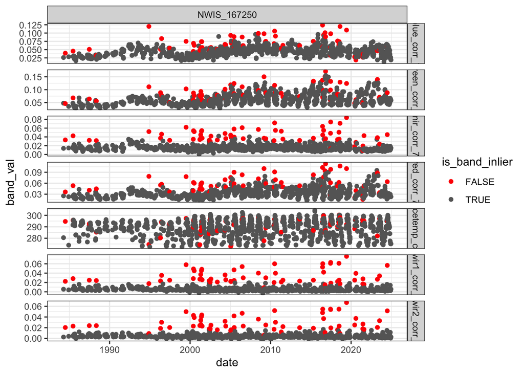

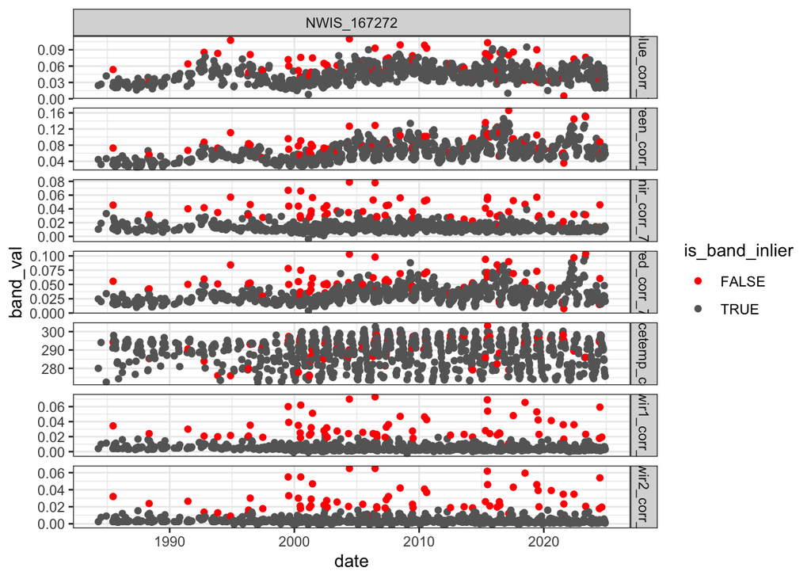

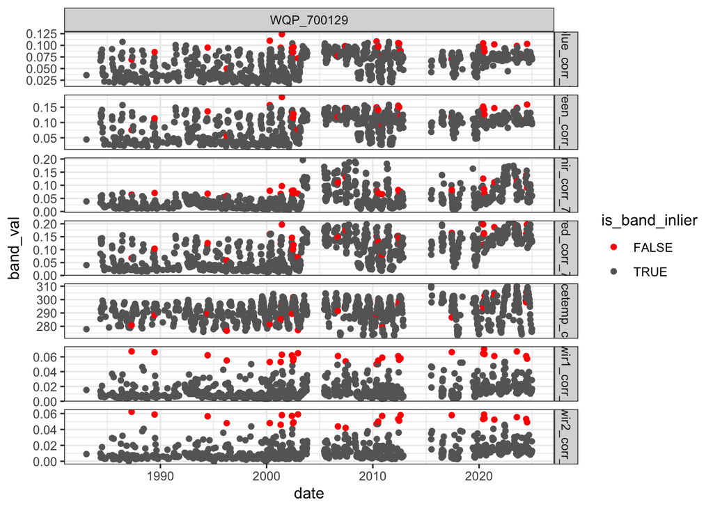

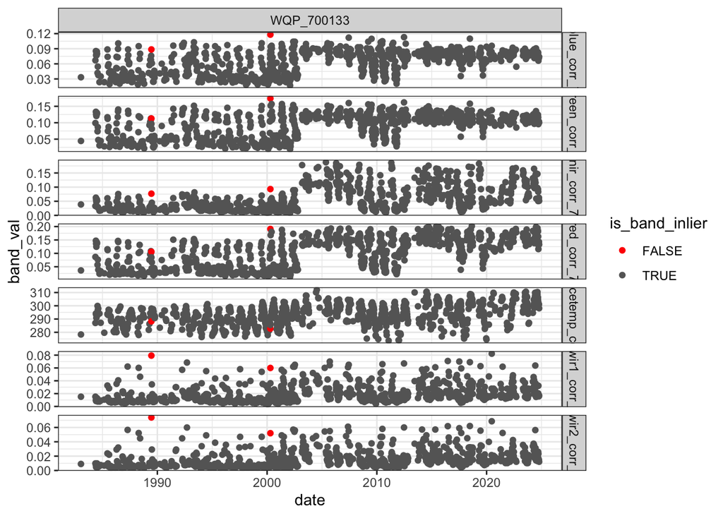

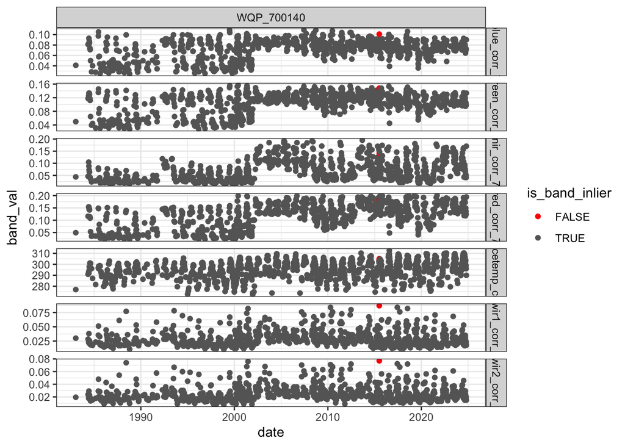

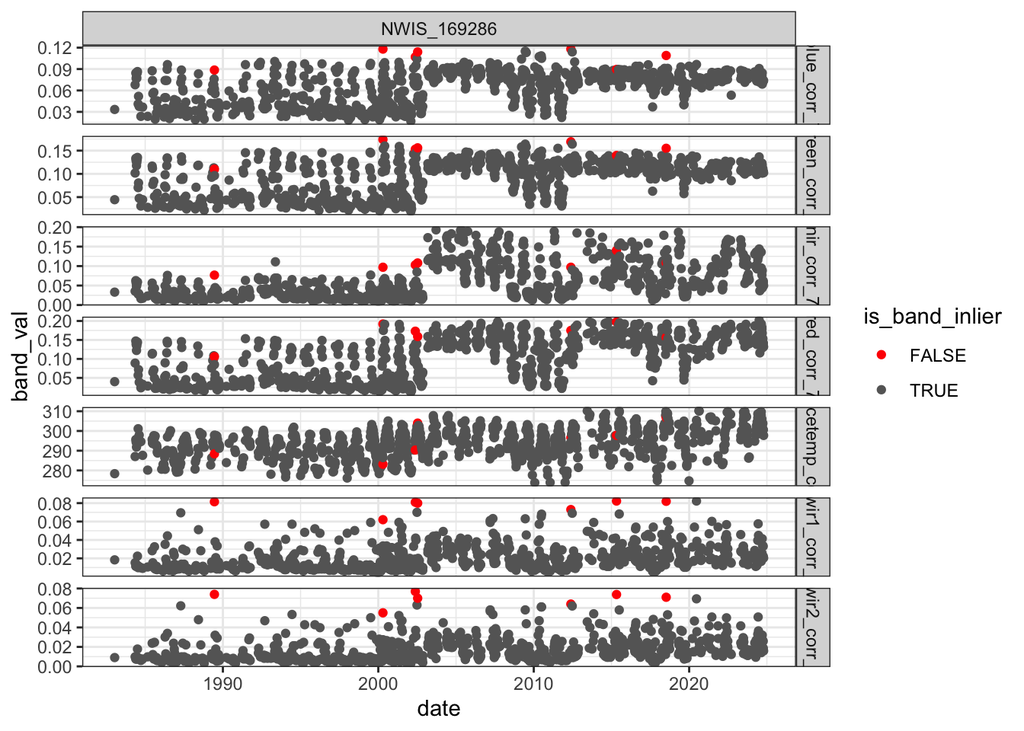

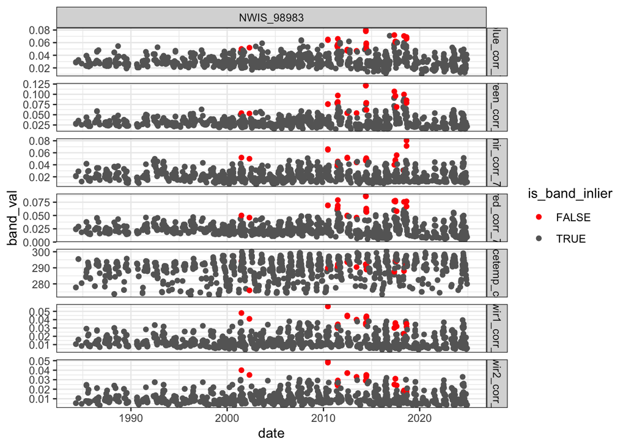

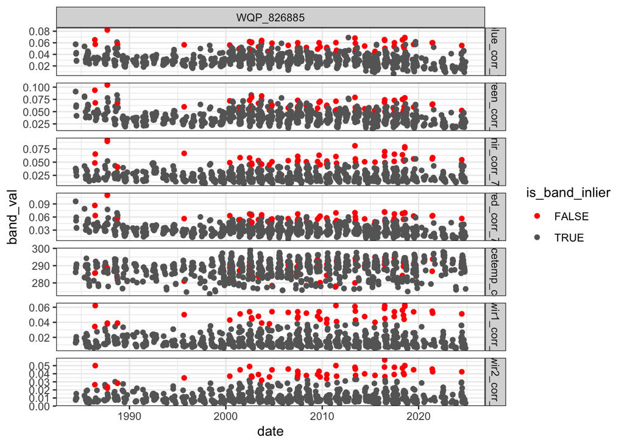

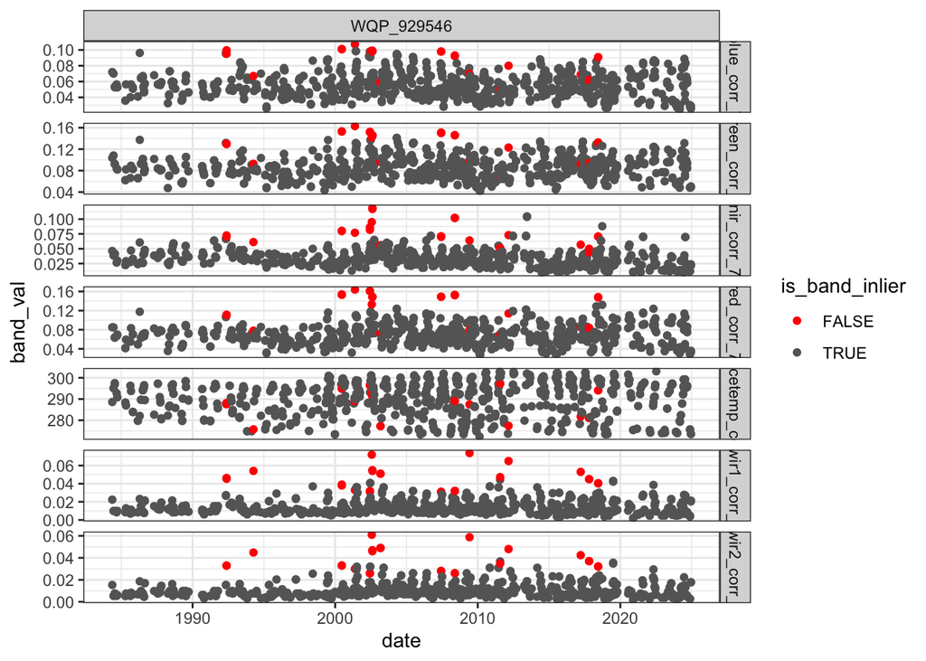

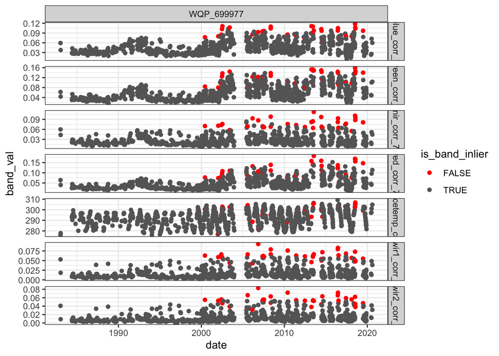

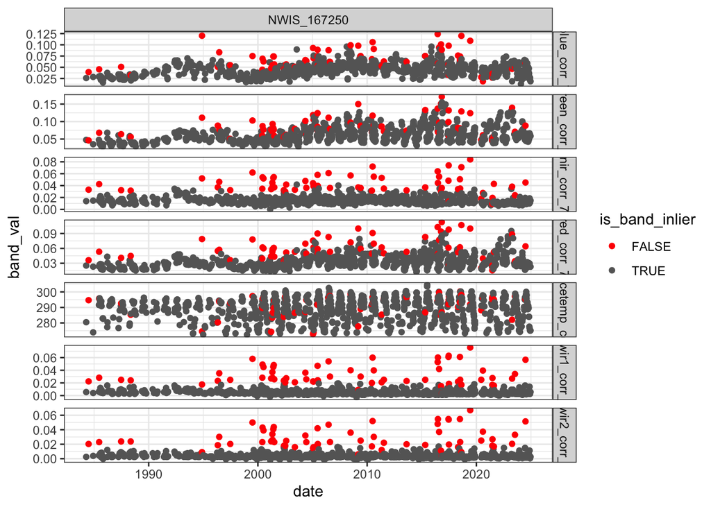

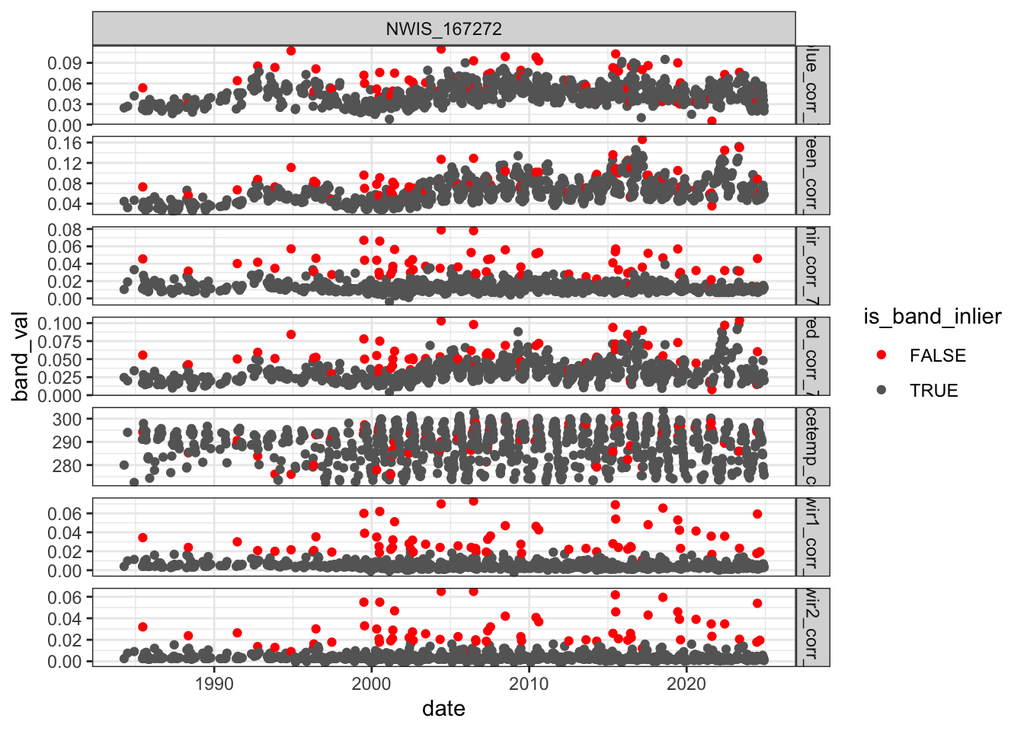

[8 more figures not shown]

```r
spotcheck_sites <- siteSR_regional_corr %>%
  group_by(siteSR_id) %>%
  summarize(n = n()) %>%
  filter(between(n, 950,960)) %>%
  collect() %>%
  pull(siteSR_id)

map(.x = spotcheck_sites,
    .f = ~ print(
      siteSR_regional_corr %>%
        filter(siteSR_id == .x) %>%
        collect() %>%
        pivot_longer(cols = all_of(band_cols),
                     names_to = "band",
                     values_to = "band_val") %>%
        ggplot(.,
               aes(x = date, y = band_val, color = is_band_inlier)) +
        geom_point() +
        facet_grid(band ~ siteSR_id, scales = "free_y") +
        scale_color_manual(values = c(`TRUE` = "grey40", `FALSE` = "red")) +
        theme_bw()
    )
)
```

Some of these look like they might belong to the same waterbody or are sites that are very close to one another, even after the de-duplication step.

Check whether flagging concentrates at reflectance extremes rather than spreading evenly across the range of each band - the same “does this look like real signal being cut, or generic scene noise” question asked of the SDD-only filter above, just against the band values themselves since no SDD/harmonized_value exists on this pre-match data. Even spreading here is consistent with catching genuine spectral noise (cloud/shadow edges, glint); concentration at one band’s extremes would suggest the filter is instead cutting real, legitimately bright or dark water.

Deciling requires the full column in memory (arrow’s Acero engine doesn’t push `ntile()` down), so this chunk collects once into a plain tibble; that same collected copy is reused by the decile10 chunks below it.

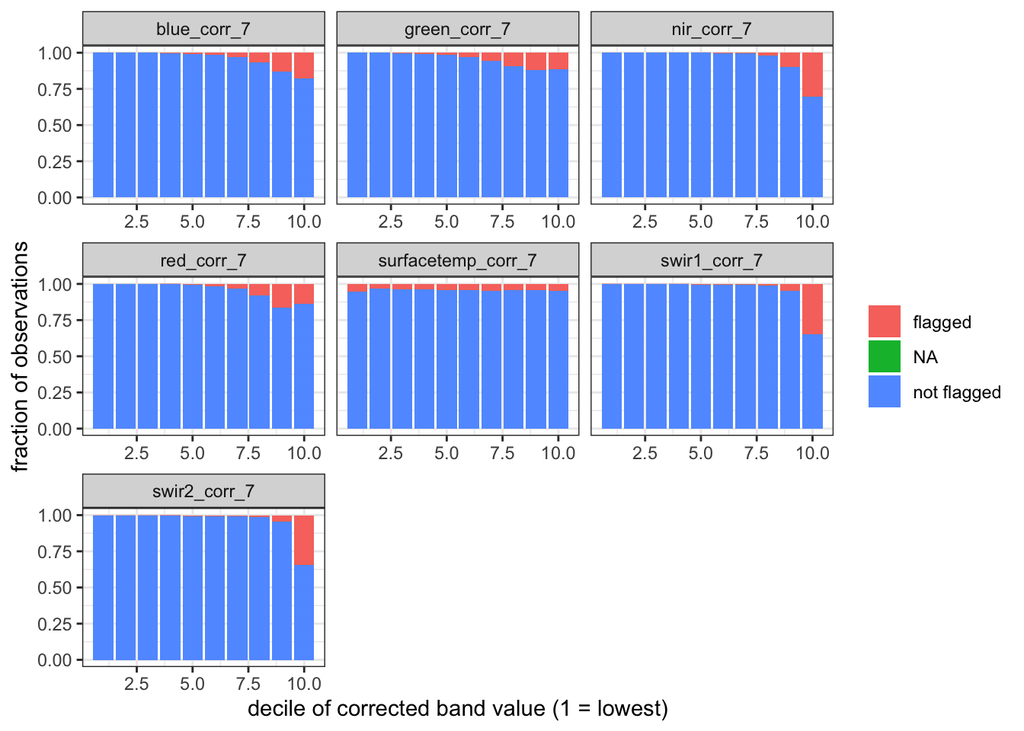

```r
siteSR_regional_corr_df <- siteSR_regional_corr %>%
  collect()

band_tail_check <- band_cols %>%
  map_dfr(function(b) {
    siteSR_regional_corr_df %>%
      transmute(band = b, bin = ntile(.data[[b]], 10), is_band_inlier)
  }) %>%
  group_by(band, bin) %>%
  summarize(n = n(),
            n_flagged = sum(is_band_inlier == FALSE, na.rm = TRUE),
            n_unflagged = sum(is_band_inlier == TRUE, na.rm = TRUE),
            n_na = sum(is.na(is_band_inlier)),
            .groups = "drop") %>%
  mutate(frac_flagged = n_flagged / n,
         frac_unflagged = n_unflagged / n,
         frac_na = n_na / n) %>%
  arrange(band, bin)

print(
  band_tail_check %>%
    pivot_longer(cols = c(frac_flagged, frac_unflagged, frac_na),
                 names_to = "status", values_to = "frac") %>%
    mutate(status = recode(status,
                           frac_flagged = "flagged",
                           frac_unflagged = "not flagged",
                           frac_na = "NA")) %>%
    ggplot(aes(x = bin, y = frac, fill = status)) +
    geom_col() +
    facet_wrap(~ band, scales = "free_x") +
    labs(x = "decile of corrected band value (1 = lowest)",
         y = "fraction of observations",
         fill = NULL) +
    theme_bw()
)
```

This does skew to flagging greater outliers at higher values, but that is probably real. We can further look into that by looking at sites where there are a lot of data being flagged in the 90th percentile.

Spot-check sites with a large enough record (> 1000 observations) that the pattern is legible, restricted to sites with at least one point in that band’s decile 10 (i.e. at/above the band’s global 90th percentile) - a closer look at the sites/points actually behind the decile-10 concentration surfaced above, to see whether those points look like isolated spectral noise or a recurring signal (e.g. seasonal bloom) the filter is cutting.

```r
band_p90 <- set_names(
  map_dbl(band_cols, ~ quantile(siteSR_regional_corr_df[[.x]], 0.9, na.rm = TRUE)),
  band_cols
)
band_p90_df <- tibble(band = band_cols, p90 = band_p90)

siteSR_band_long <- band_cols %>%
  map_dfr(function(b) {
    siteSR_regional_corr_df %>%
      transmute(siteSR_id, date, band = b, band_val = .data[[b]], is_band_inlier)
  })

large_sites <- siteSR_regional_corr %>%
  group_by(siteSR_id) %>%
  summarize(n = n()) %>%
  filter(n > 1000) %>%
  collect() %>%
  pull(siteSR_id)

decile10_sites_all <- siteSR_band_long %>%
  filter(siteSR_id %in% large_sites, band_val >= band_p90[band]) %>%
  distinct(siteSR_id) %>%
  pull(siteSR_id)

# this condition flags the vast majority of large sites (a decile-10 hit in
# any of 7 bands is a low bar), so plotting all of them stops being a spot
# check - sample a fixed, reproducible subset instead
set.seed(43)
decile10_spotcheck_n <- 25
decile10_sites <- if (length(decile10_sites_all) > decile10_spotcheck_n) {
  sample(decile10_sites_all, decile10_spotcheck_n)
} else {
  decile10_sites_all
}
```

One figure per site, rather than one huge multi-site `facet_grid`, so each site’s timeseries is actually readable. 459 sites meet the decile10 criterion above; we spot-check a random sample of 25 of them here rather than rendering all of them.